# Exploratory Data Analysis

Maria Cuellar

2025-09-16

# The grammar of graphics

The Grammar of Graphics was a book published in 1999 by a statistician named Leland Wilkinson, and later Hadley Wickham used it to write a package called ggplot in R. ggplot stands for Grammar of Graphics plot.

It is called a grammar because it is a structure for producing plots that resembles a language. Nearly every current software tool used to build plots has been informed by this book. Its influence can be found in Tableau, Plotly, and the Python libraries bokeh, altair, seaborn, and plotnine. The most complete implementation of the grammar is found in an R package called ggplot2 by Hadley Wickham.

[figure not shown]

In Wickham’s adaptation of the grammar of graphics, a plot can be decomposed into seven elements:

- **Data**: The data frame that contains the data you want to visualize.
- **Aesthetic** (aes) mapping of the variables in the data to visual cues: What is your x or y.

Why it’s called “aesthetics”: It’s not about style or beauty — it’s about visual mappings. An aesthetic is anything that controls what you see on the plot. (x and y, color, fill, shape, size, alpha (transparency), linetype). This contrasts with “settings”. If you don’t want an aesthetic to depend on data, you set it outside aes(). For example: `ggplot(mtcars, aes(x = mpg, y = hp)) + geom_point(color = "red")`.

- **Geometry**: Is used to encode the observations on the plot: What kind of plot you’re making, a histogram, a bar plot, a line, etc.
- **Facets**: If you want to split up the plots by categories, e.g., one plot for females and one for males.

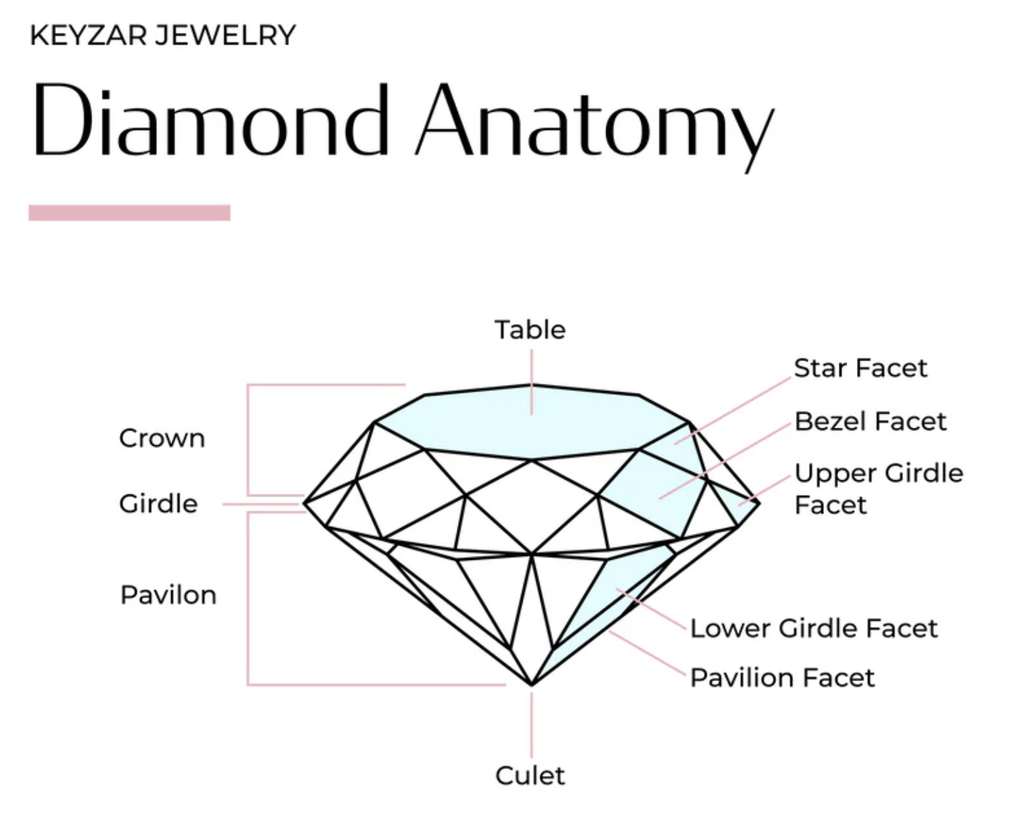

- **Statistics**: If you want to fit a model to the data. Geoms decide how to draw (points, lines, bars). Stats decide what to draw by computing summaries (counts, means, model fits).
- **Coordinates**: If you want to change the scales. Theme: If you want to make it pretty.

# ggplot components

We will use the `mpg` dataset, which is built into the `ggplot2` package, which is part of the `tidyverse` package.

We will use the variables `cty` and `hwy` as our quantitative variables, and the variables `drv`, `cyl` as our categorical ones.

```r
# load packages
library(tidyverse)
library(ggthemes)
```

If you only use ggplot, then nothing happens.

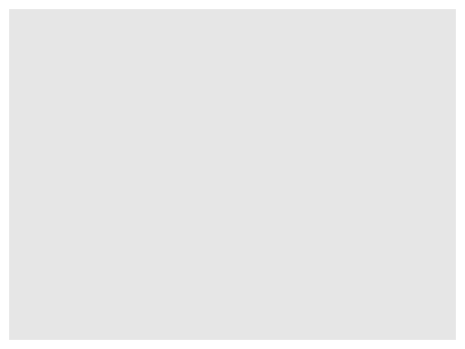

```r
mpg %>% ggplot()
```

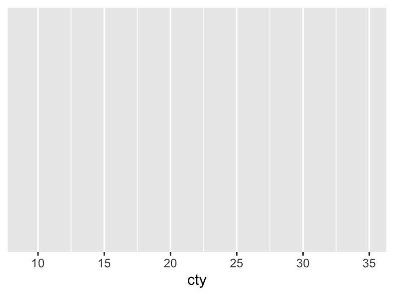

```r
mpg %>% ggplot(aes(x=cty))
```

If you then add the geometry (shortened as geom), then you get a plot.

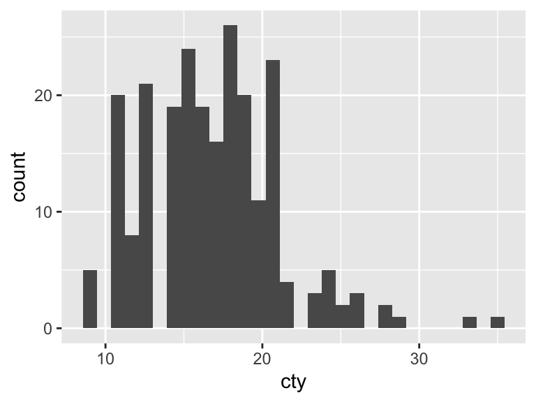

```r
mpg %>% ggplot(aes(x=cty)) + geom_histogram()
```

You can change the color of the points for fun, without having any particular meaning. Note that there is no legend. This is SETTING a constant color, not mapping (no legend). That’s why it’s outside aes.

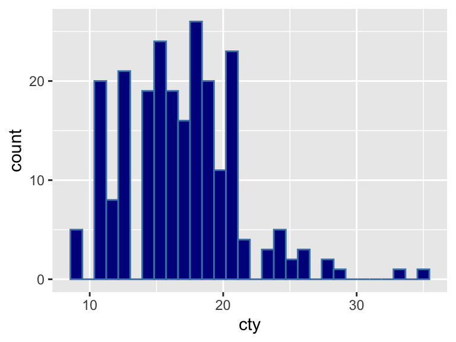

```r
mpg %>% ggplot(aes(x=cty)) + geom_histogram(color = "steelblue", fill="darkblue")
```

Or you can use color with meaning. Here we use it to tell us how the points split up by a third categorical variable, drv. This splits up the points by color, one for each category of drv. This is MAPPING color to a variable (legend appears).

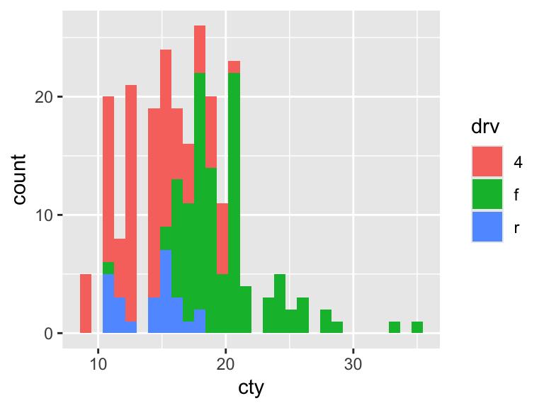

```r
mpg %>% ggplot(aes(x=cty, fill = drv)) + geom_histogram()
```

You can use facets instead to see the differences in the points according to a third categorical variable. This splits up the plot into three plots, one for each category of drv.

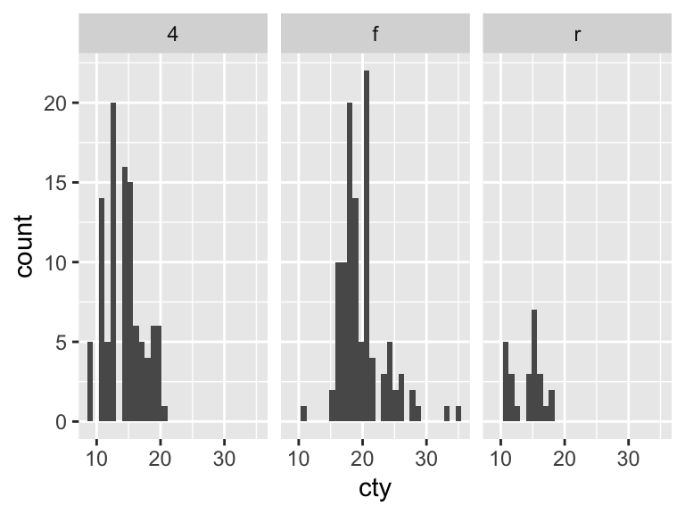

```r
mpg %>% ggplot(aes(x=cty)) + geom_histogram() + facet_grid(~drv)
```

You can also change the coordinates (although we won’t do this often).

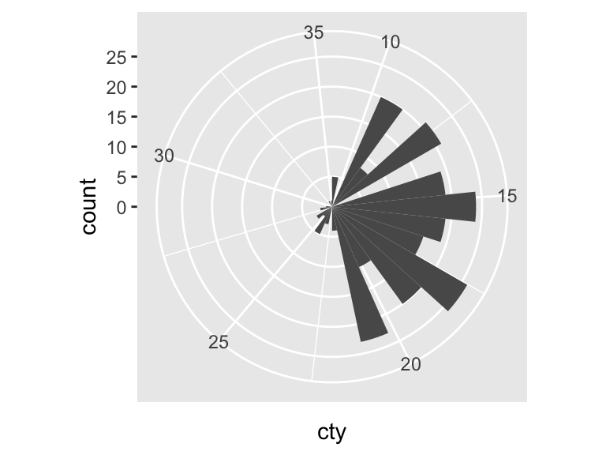

```r
# coord_polar() for pie/polar charts
mpg %>% ggplot(aes(x=cty)) + geom_histogram() + coord_polar()
```

You can add “statistics”, meaning some modeling to your plot. Note that ggplot is doing this in the background - we will learn later how to model ourselves.

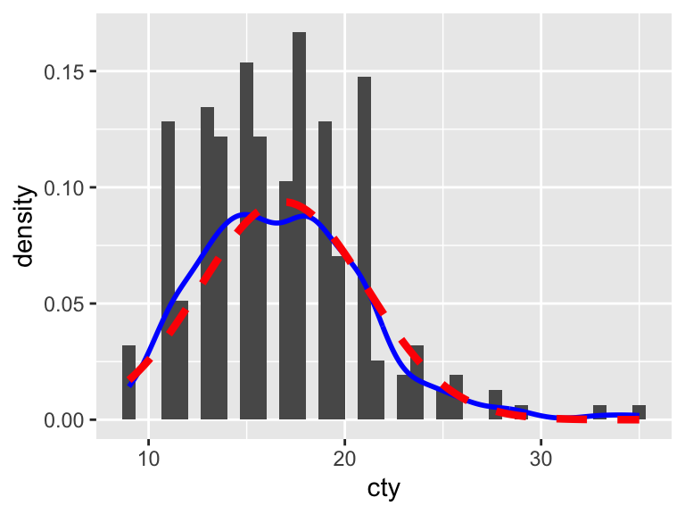

```r
mpg %>% ggplot(aes(x=cty)) +
  geom_histogram(bins=40, aes(y = after_stat(density))) +
  stat_density(geom = "line", color = "blue", linewidth = 1) + # Computes a kernel density estimate
  stat_function(fun = dnorm,
                args = list(mean = mean(mpg$cty), sd = sd(mpg$cty)),  # Plots any function (e.g., theoretical Normal distribution)
                color = "red", linetype = "dashed", linewidth=1.5)
```

Finally, you can change the look of the plot.

**Themes**

Themes are made for you:

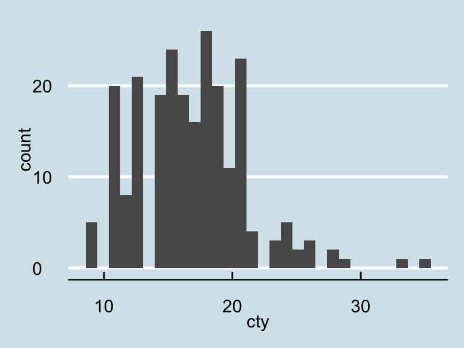

```r
mpg %>% ggplot(aes(x=cty)) + geom_histogram() + theme_economist()
```

```r
# make sure you've loaded the ggthemes package
```

You can see more options here: https://yutannihilation.github.io/allYourFigureAreBelongToUs/ggthemes/

**Palettes**

And you can also change the palettes. There’s a nice set of palettes called the Brewer palettes: https://r-graph-gallery.com/38-rcolorbrewers-palettes.html. Designed by Cynthia Brewer: https://en.wikipedia.org/wiki/Cynthia_Brewer.

There’s a nice interactive code you can play around with, that shows how color is used in ggplot, here: https://r-graph-gallery.com/ggplot2-color.html

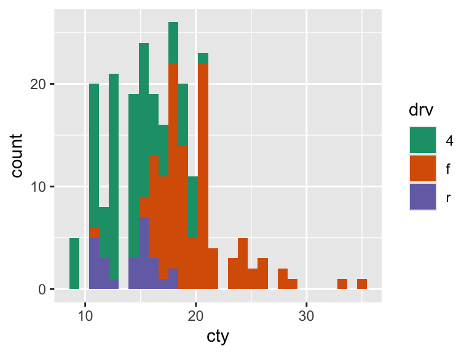

```r
library(tidyverse)
mpg %>% ggplot(aes(x=cty, fill=drv)) + geom_histogram() + scale_fill_brewer(palette = "Dark2")
```

# Single variable EDA

## Quantitative varible:

*Visual EDA*

**Histogram**

Plot a histogram to visualize a single quantitative variable.

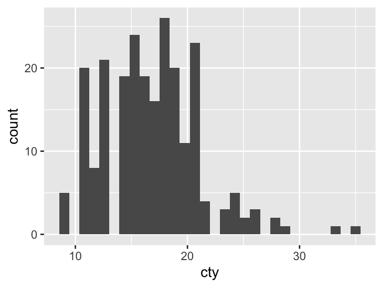

```r
mpg %>% ggplot(aes(x=cty)) + geom_histogram()
```

**Boxplot**

Plot a boxplot to visualize a single quantitative variable.

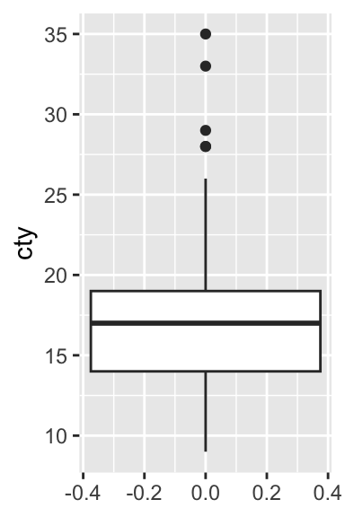

```r
mpg %>% ggplot(aes(y=cty)) + geom_boxplot()
```

*Quantitative EDA*

To summarize a quantitative variable, first determine how many modes the distribution has. If it’s uniform, then report the range of the variable.

```r
# If uniform (which is not the case for cty, but I'll show you how to calculate a range with it anyway):
range(mpg$cty)
```

```
## [1]  9 35
```

If it’s multimodal, then see if you can split up the distribution into its modes, by using a categorical variable. If not, then you can just report where the modes are.

If it’s unimodal, then you can give measures of its centrality and spread. If it’s symmetric, then give the mean and standard deviation, and if it’s asymmetric, give the median and IQR. Note that if the mean and the median are equal, then this shows you that the distribution is symmetric.

```r
# If unimodal and symmetric:
mpg %>% summarize(mean=mean(cty), sd=sd(cty))
```

```
## # A tibble: 1 × 2
##    mean    sd
##   <dbl> <dbl>
## 1  16.9  4.26
```

```r
# If unimodal and assymetric:
mpg %>% summarize(median=median(cty), IQR=IQR(cty))
```

```
## # A tibble: 1 × 2
##   median   IQR
##    <dbl> <dbl>
## 1     17     5
```

## Categorical variable

*Visual EDA*

**Barplot**

Draw a barplot to visualize a single categorical variable.

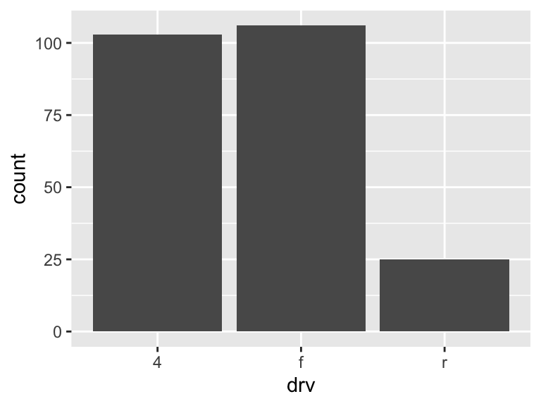

```r
mpg %>% ggplot(aes(x=drv)) + geom_bar()
```

**Pie chart**

(Actually, don’t use pie charts. They’re often more deceiving than helpful - this is because humans are bad at comparing areas to each other. Just stick to barplots, or tables.)

```r
#mpg %>% ggplot(aes(x="", fill=drv)) + geom_bar() + coord_polar("y") + theme_void()
```

*Quantitative EDA*

How to make a table to summarize a categorical variable:

```r
dat_students <- read_csv("/Users/mariacuellar/Github/crim_data_analysis/data/students.csv")
dat_students %>% count(year_in_college)
```

```
## # A tibble: 4 × 2
##   year_in_college     n
##   <chr>           <int>
## 1 First year       2129
## 2 Fourth year      2108
## 3 Second year      3144
## 4 Third year       3116
```

How to add proportions:

```r
dat_students %>%
  count(year_in_college) %>%
  mutate(prop = n / sum(n))
```

```
## # A tibble: 4 × 3
##   year_in_college     n  prop
##   <chr>           <int> <dbl>
## 1 First year       2129 0.203
## 2 Fourth year      2108 0.201
## 3 Second year      3144 0.300
## 4 Third year       3116 0.297
```

# Two variable EDA

## Two categorical variables

*Visual EDA*

**Side-by-side barplots**

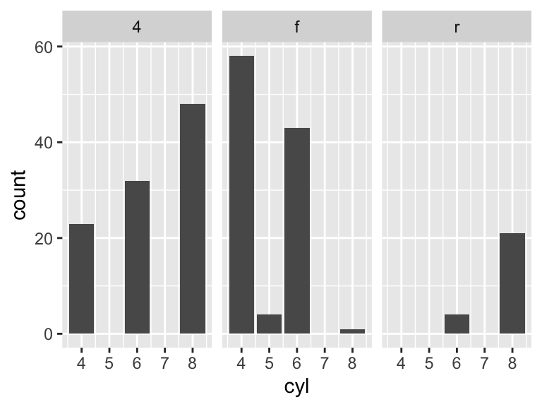

```r
mpg %>% ggplot(aes(x=cyl)) + geom_bar() + facet_wrap(~drv)
```

**Different color barplots**

Note: position dodge is almost always prefereable to identity because identity stacks the bars up, and it’s very difficult for humans to compare the sizes of the bars when they start at different heights.

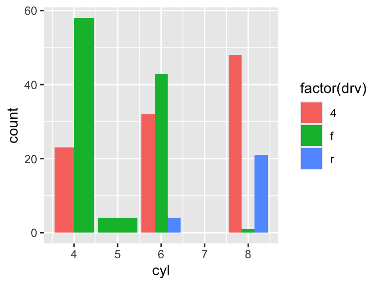

```r
mpg %>% ggplot(aes(x=cyl, fill=factor(drv))) + geom_bar(position="dodge")
```

```r
# note that sometimes if you don't add factor for the aesthetics, ggplot gets confused
```

*Quantitative EDA*

You can make a two-way contingency table. (For higher dimensions, let’s say you want to compare three categorical variables, then you can also do a three-way contingency table.)

```r
# in tidyverse
mpg %>%
  count(cyl, drv) %>%
  pivot_wider(
    names_from = drv,
    values_from = n,
    values_fill = 0
  )
```

```
## # A tibble: 4 × 4
##     cyl   `4`     f     r
##   <int> <int> <int> <int>
## 1     4    23    58     0
## 2     5     0     4     0
## 3     6    32    43     4
## 4     8    48     1    21
```

```r
# the code is simpler in base R...
table(mpg$cyl, mpg$drv)
```

```
##
##      4  f  r
##   4 23 58  0
##   5  0  4  0
##   6 32 43  4
##   8 48  1 21
```

## A quantitative variable and a categorical variable

*Visual EDA*

**Side-by-side histograms**

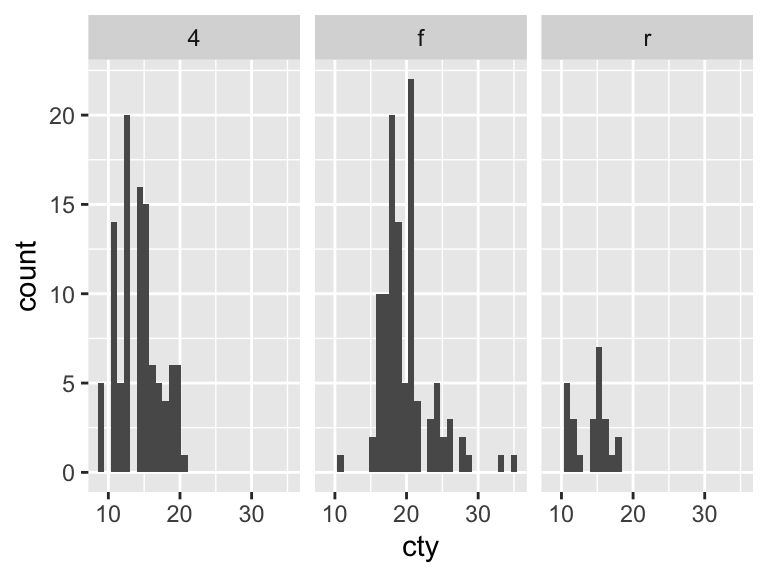

```r
mpg %>% ggplot(aes(x=cty)) + geom_histogram() + facet_grid(~drv)
```

**Side-by-side boxplots**

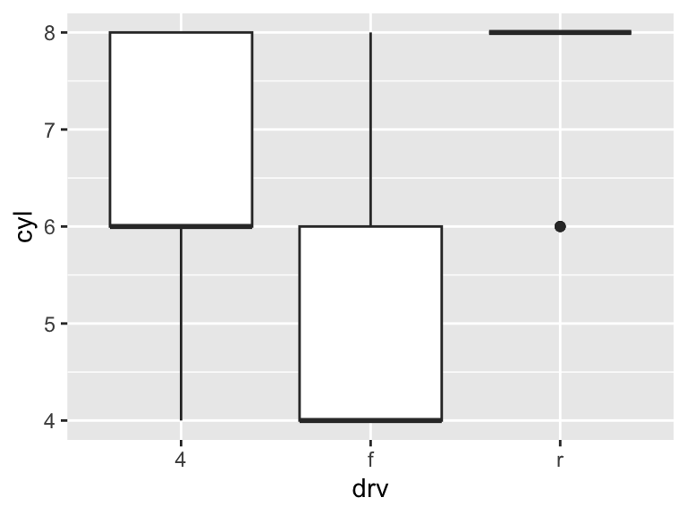

```r
mpg %>% ggplot(aes(y=cyl, x=drv)) + geom_boxplot()
```

**Different color histograms**

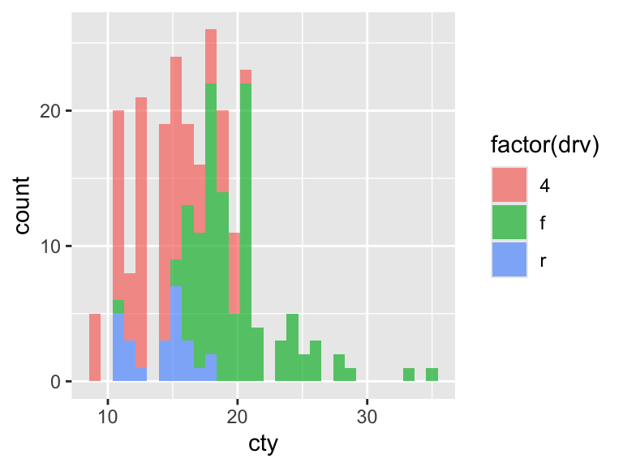

```r
mpg %>% ggplot(aes(x=cty, fill=factor(drv))) + geom_histogram(alpha=.7)
```

*Quantitative EDA*

You can give the summary statistics (same as for a histogram), but for each histogram.

## Two quantitative variables

*Visual EDA*

**Scatterplot**

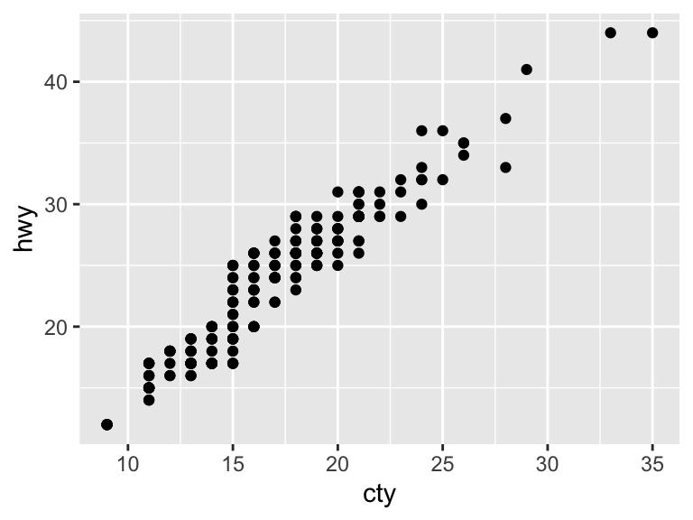

```r
mpg %>% ggplot(aes(x=cty, y=hwy)) + geom_point()
```

# Three variable EDA

## Three categorical variables

*Visual EDA*

*Quantitative EDA*

Three-way contingency table.

## Two quantitative variables and a categorical variable

**Scatterplot with different colors by the categories**

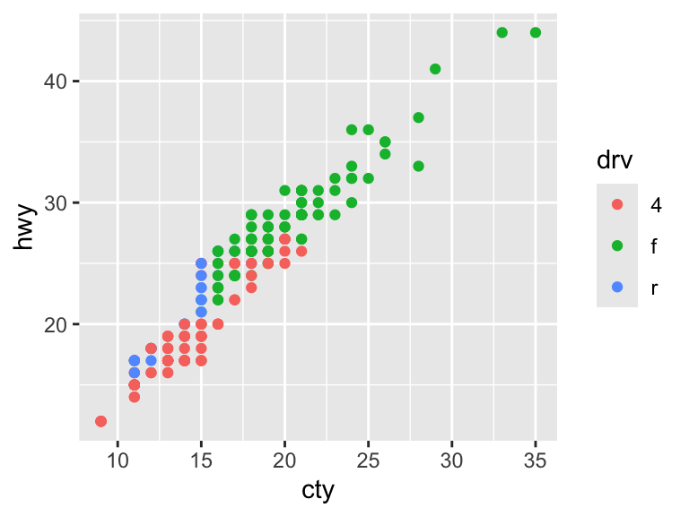

```r
mpg %>% ggplot(aes(x=cty, y=hwy, color=drv)) + geom_point()
```

## Three quantitative variables

**Scatterplot with different colors by the shade of the third quantitative variable**

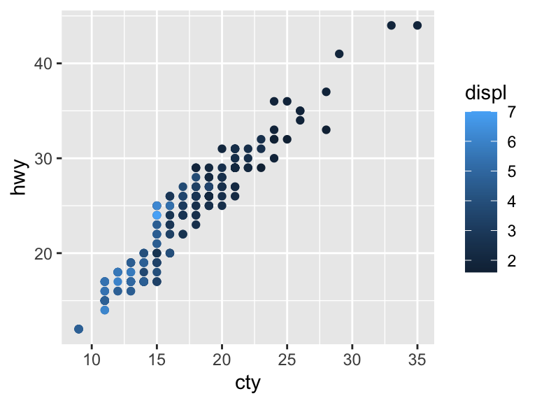

```r
mpg %>% ggplot(aes(x=cty, y=hwy, color=displ)) + geom_point()
```